# Creating Social Network Datasets

Nicole Jess, Yuqing Liu

2023-01-24, 16:07:59 EST

# 1 Purpose

The script restructures data scraped from twitter into a format that can be used for social network analysis.

# 2 Load R Packages

Load contributed R packages that we need to get additional functions.

```r
library(tidyverse)          # dplyr, ggplot2, tidyr, etc.
library(here)               # for here()
library(knitr)              # for kable()
library(academictwitteR)    # for get_user_profile()
library(linkcomm)           # for integer.edgelist()
library(igraph)             # for graph_from_data_frame()
```

# 3 Load data

```r
# Data file created by "scripts/scrape_tweets.Rmd"
load(file=here("data/t2.RData"))
load(file=here("data/tweet_authors.RData"))
```

# 4 Edgelist

## 4.1 Replys

```r
replies <- t2 %>%
  select(id_str, created_at, in_reply_to_user_id_str, full_text) %>%
  drop_na() %>%
  mutate(edge_type="replies") %>%
  left_join(tweet_authors, by=c("id_str"="id")) %>%
  rename(tweet_id=id_str,
         from=author_id,
         to=in_reply_to_user_id_str,
         text=full_text) %>%
  relocate(tweet_id, created_at, from, to, text, edge_type)
```

## 4.2 Retweets

```r
retweets<- t2$retweeted_status %>%
  map("user") %>%
  map_df(bind_rows) %>%
  mutate(tweet_id=t2$id_str,
         text=t2$full_text,
         created_at=t2$created_at,
         edge_type="retweets") %>%
  drop_na(id_str) %>%
  left_join(tweet_authors, by=c("tweet_id"="id")) %>%
  rename(from=author_id,
         to=id_str) %>%
  select(tweet_id, created_at, from, to, text, edge_type)
```

## 4.3 Quotes

```r
quotes<- t2$quoted_status %>%
  map("user") %>%
  map_df(bind_rows) %>%
  mutate(tweet_id=t2$id_str,
         text=t2$full_text,
         created_at=t2$created_at,
         edge_type="quotes") %>%
  drop_na(id_str) %>%
  left_join(tweet_authors, by=c("tweet_id"="id")) %>%
  rename(from=author_id,
         to=id_str) %>%
  select(tweet_id, created_at, from, to, text, edge_type)
```

## 4.4 Mentions

```r
mentions <- t2$entities %>%
  map("user_mentions") %>%
  map("id_str") %>%
  plyr::ldply(rbind) %>%
  mutate(tweet_id=t2$id_str,
         text=t2$full_text,
         created_at=t2$created_at,
         edge_type="mentions") %>%
  pivot_longer(-c("tweet_id","text","created_at","edge_type"), values_to="to") %>%
  drop_na(to) %>%
  left_join(tweet_authors, by=c("tweet_id"="id")) %>%
  rename(from=author_id) %>%
  select(tweet_id, created_at, from, to, text, edge_type)
```

## 4.5 Combine edge types

You can remove edge types that are not of interest for your project. For example, if you do not want replies to be counted as edges in your network, delete “replies” from the code below.

```r
edgelist <- bind_rows(replies,
                      retweets,
                      quotes,
                      mentions)
```

Altogether, this gives us a total of 11293 edges in this network. Table 4.1 shows the total number of each edge type in this network.

```r
TC <- paste0("Total edges by edge type ")

table(edgelist$edge_type) %>%
  addmargins(1,sum) %>%
  kable(col.names=c("edge type","n"),
        caption=TC)
```

Table 4.1: Total edges by edge type

| edge type | n |
| --- | --- |
| mentions | 6762 |
| quotes | 280 |
| replies | 787 |
| retweets | 3464 |
| sum | 11293 |

# 5 Integer edgelist

Some of the tools we work with require that the edge IDs are integers starting with 1. This code creates and edgelist that meets these requirements.

```r
# integer edgelist
network1 <- edgelist %>%
  select(from,to) %>%
  as.matrix() %>%
  integer.edgelist()

edges <- network1$edges %>%
  as.data.frame() %>%
  rename(from = V1,
         to = V2) %>%
  group_by(from,to) %>%
  summarize(weight = n()) %>%
  filter(from != to) %>%    # remove self-ties
  as.data.frame()

# save indegree and outdegree to use as node attributes
indegree <- edges %>%
  group_by(to) %>%
  summarize(indegree=n()) %>%
  as.data.frame()

outdegree <- edges %>%
  group_by(from) %>%
  summarize(outdegree=n()) %>%
  as.data.frame()
```

# 6 Nodelist

This code creates a list of all the nodes in the network and scrapes data from the Twitter user profiles.

```r
nodelist <- c(edgelist$from, edgelist$to) %>%
  unique() %>%
  get_user_profile(get_bearer()) %>%
  select(-starts_with("entities"))
```

[output not shown]

```r
# match integer IDs to node attributes
nodes <- network1$nodes %>%
  as.data.frame() %>%
  rename(nodes = 1) %>%
  mutate(id = rownames(.)) %>%
  left_join(nodelist, by="id") %>%
  left_join(indegree, by=c("nodes"="to")) %>%
  left_join(outdegree, by=c("nodes"="from")) %>%
  mutate_at(vars(c(indegree,outdegree)), ~replace(., is.na(.), 0)) %>%
  mutate(degree = indegree + outdegree)
```

# 7 Testing an *igraph* object

This code creates and plots an *igraph* object to test that the integer edgelist works properly. Figure 7.1 probably doesn’t look very nice but for this script we just want to confirm that we are able to make a graph. Other scripts in this repository have code for making better graphs.

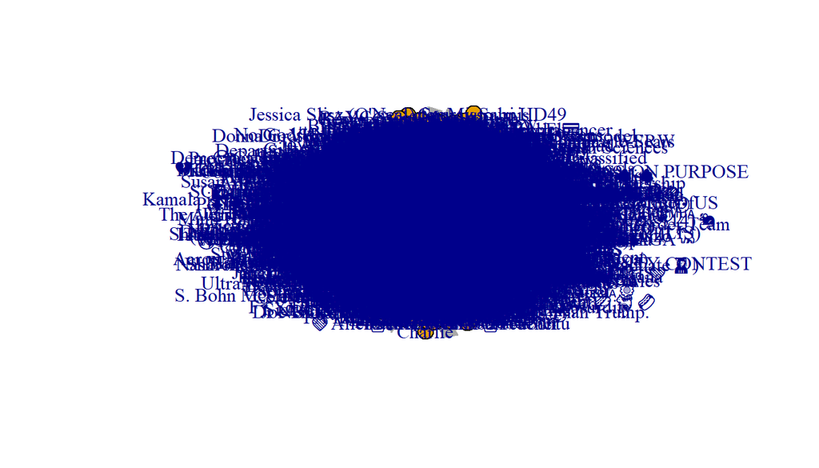

Figure 7.1: Plot of network

```r
FC <- paste0("\\label{fig:igraph}",
            "Plot of network ")

# create an igraph object
net1 <- graph_from_data_frame(d = edges,
                              vertices = nodes,
                              directed = TRUE)

plot(net1)
```

# 8 Save Data

```r
# here() creates a path relative to the location of the twitter-sna.proj file
# that will be portable across local repositories on different computers.

save(edgelist, file=here("data/twitter_edges.RData"))
save(nodelist, file=here("data/twitter_nodes.RData"))
save(edges, file=here("data/int_edges.RData"))
save(nodes, file=here("data/int_nodes.RData"))
```